# Practical Machine Learning Course Project

Dennis Barger

May 23, 2015

## Overview

### Background Information

The rise of “Quantified Self Movement” analytics has expanded the use of devices for tracking personal health actvitiies. Research into human activity recognition was conducted with six participants on the correct and incorrect usage of barbell during weight lifting exercises. THe approach taken by the research team was to investigate how well an activity was performed by the participants.

Participants were asked to complete one set of ten repetitions of Unilateral Dumbbell Biceps Curl in five different methods:

- Class A - Exactly according to specifications
- Class B - Throwing elbows to the front
- Class C - Lifting dumbbell only halfway
- Class D - Lowering dumbbell only halfway
- Class E - Throwing hips to the front

### Project Objectives

The primary objective of the Practical Machine Learning Course project is to utilize data from the Human Activity Recognition (HAR) project and predict how well the participants conducted weight lifting exercises. The analysis should use the “Classe” variable and any other variable deemed relevant by the student.

### Data Source

The “Weight Lifing Exercises” dataset created in suppor of the Human Activity Recognition project is being used for the course project. The dataset is available at http://groupware.les.inf.puc-rio.br/har#weight_lifting_exercises.

Two data files were created for the course project:

- Training Dataset: [https://d396qusza40orc.cloudfront.net/predmachlearn/pml-training.csv]
- Test Dataset: [https://d396qusza40orc.cloudfront.net/predmachlearn/pml-testing.csv]

## Data Preparation

### Data Cleansing

The training and test datasets were cleansed in order to eliminate any discrepancies due to missing data, whether inputing individual values or removing entire columns.

```r
require("caret")
require("randomForest")
require("rpart")
```

```r
library(caret)
library(randomForest)
library(rpart)
library(rpart.plot)
set.seed(0)
setwd("c:\\data\\coursera\\predmachlearn")
fileTrain <- "./pml-training.csv"
fileTest <- "./pml-testing.csv"

# Change bad/missing values to NA
dfTrain <- read.csv(fileTrain,header=TRUE,sep=",",na.strings=c("NA","#DIV/0!",""))
dfTest <- read.csv(fileTest,header=TRUE,sep=",",na.strings=c("NA","#DIV/0!",""))

# Check current dimensions in datasets
dim(dfTrain)
```

```
## [1] 19622   160
```

```r
dim(dfTest)
```

```
## [1]  20 160
```

```r
# Remove columns that are completely empty or not needed for analysis
dfTrain <- dfTrain[,colSums(is.na(dfTrain)) == 0]
dfTrain <- dfTrain[, -c(1:7)]
dfTest <- dfTest[,colSums(is.na(dfTest)) == 0]
dfTest <- dfTest[, -c(1:7)]

# Check dimensions in revised datasets
dim(dfTrain)
```

```
## [1] 19622    53
```

```r
dim(dfTest)
```

```
## [1] 20 53
```

### Data Partitioning

```r
inTrain <- createDataPartition(y=dfTrain$classe, p=0.75, list=FALSE)
dfTrainSet <- dfTrain[inTrain,]
dfTestSet  <- dfTest[-inTrain,]

dim(dfTrainSet)
```

```
## [1] 14718    53
```

```r
dim(dfTestSet)
```

```
## [1]  5 53
```

### Summary of Training Dataset

There is a greater frequency of participants completing the exercise correctly (i.e. Classe A) in comparison to other exercise classes.

```r
dat <- table(dfTrainSet$classe)
dat
```

```
##
##    A    B    C    D    E
## 4185 2848 2567 2412 2706
```

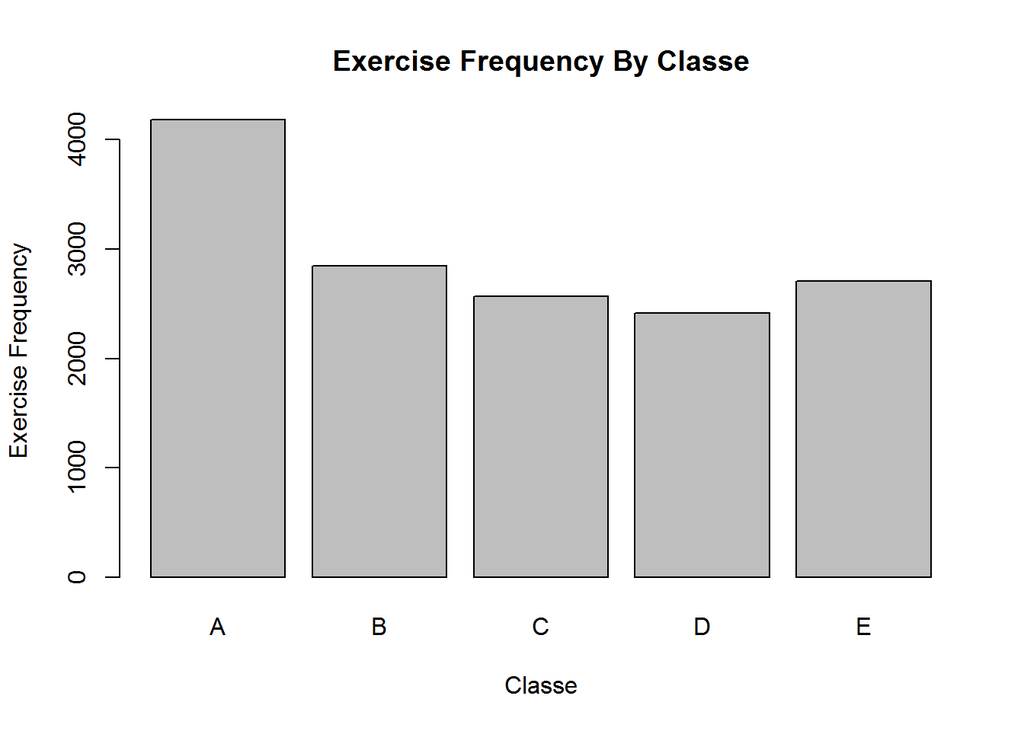

```r
barplot(dat,main="Exercise Frequency By Classe",xlab="Classe",ylab="Exercise Frequency")
```

```r
# plot(dfTrainSet$classe,main="Exercise Frequency By Classe:  Training Dataset", xlab="Classe", ylab="Exercise Frequency")
```

## Modeling

### Predicting with Random Forest

```r
# Cleanup unused variables to reduce memory issues
rm(inTrain)
rm(dfTrain)
rm(dat)

model <- randomForest(classe ~ ., data=dfTrainSet, method="class")
prediction <- predict(model,dfTestSet,type="class")
```

## Project Submission

```r
results <- predict(model, dfTest, type="class")

pml_write_files = function(x) {
    n = length(x)
    for(i in 1:n) {
        filename = paste0("problem_id_",i,".txt")
        write.table(x[i], file=filename, quote=FALSE, row.names=FALSE,col.names=FALSE)
    }
}

pml_write_files(results)
```

## References

Velloso, E.; Bulling, A.; Gellersen, H.; Ugulino, W.; Fuks, H. Qualitative Activity Recognition of Weight Lifting Exercises. Proceedings of 4th International Conference in Cooperation with SIGCHI (Augmented Human ’13) . Stuttgart, Germany: ACM SIGCHI, 2013.